# Spatial Queries: Find Yosemite POIs in the Merced Watershed

In this Notebook we’ll use geoprocessing functions from `sf` to identify Yosemite Points-of-Interest that fall within the **Merced watershed**.

## Setup

Load the packages we’ll need and set tmap mode to ‘plot’:

```r
library(sf)
library(tmap)
tmap_mode("plot")
```

```
tmap mode set to plotting
```

Load `dplyr` and set name conflict preferences:

```r
library(dplyr)

## Load the conflicted package
library(conflicted)

# Set conflict preferences
conflict_prefer("filter", "dplyr", quiet = TRUE)
conflict_prefer("count", "dplyr", quiet = TRUE)
conflict_prefer("select", "dplyr", quiet = TRUE)
conflict_prefer("arrange", "dplyr", quiet = TRUE)
```

## Import the Watersheds

Start by importing the watersheds, grouping by the column HU (larger watershed units). Note how `group_by()` also aggregates (i.e., unions) spatial features associated with each unique value of the attribute:

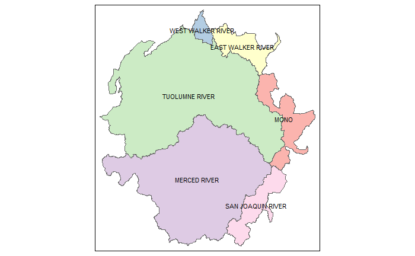

```r
## Import the watersheds, grouping by HU
gpkg_watershd_fn <- "./data/yose_watersheds.gpkg"
yose_watersheds_hu <- st_read(gpkg_watershd_fn, layer="calw221") %>%
  group_by(HU) %>%
  summarise(HUNAME = first(HUNAME), NUM_WATERSHEDS = n())
## Plot results
tm_shape(yose_watersheds_hu) +
  tm_polygons("MAP_COLORS", palette = "Pastel1") +
  tm_text("HUNAME", size = 0.7)
```

Next, pull out just the Merced River watershed and save it as a separate sf object:

```r
## Filter out just the Merced River watershid
merced_watershed <- yose_watersheds_hu %>%
  filter(HUNAME == "MERCED RIVER")
```

## Import the Points-of-Interest

Import the POIs:

```r
## Import points of interest
yose_poi_utm <- st_read(dsn="./data", layer="yose_poi") %>%
  select(OBJECTID, POINAME, POILABEL, POITYPE)
```

## Identify Points Which Intersect

Find out which POIs intersect the Merced River Watershed with `st_intersects()`:

```r
try(merced_poi <- yose_poi_utm %>% st_intersects(merced_watershed))
```

```
Error in st_geos_binop("intersects", x, y, sparse = sparse, prepared = prepared,  :
  st_crs(x) == st_crs(y) is not TRUE
```

Oh no - **ERROR message**! Spatial querying requires features to be in the same CRS!

To fix this, we can project the HU watershed layer (which is in Albers) to match the POIs (which are UTM):

```r
merced_hu_utm <- merced_watershed %>%
  st_transform(st_crs(yose_poi_utm))
```

Try the intersection test again:

```r
yose_poi_merced_mat <- yose_poi_utm %>% st_intersects(merced_hu_utm, sparse=FALSE)
head(yose_poi_merced_mat)
```

```
     [,1]
[1,] TRUE
[2,] TRUE
[3,] TRUE
[4,] TRUE
[5,] TRUE
[6,] TRUE
```

**CHALLENGE** How many points-of-interest fall within the Merced Rivershed watershed polygon? [Answer](https://bit.ly/3rEOnzn)

*Hint 1*: This is equivalent to asking how many TRUE values there are in the first column of `yose_poi_merced_mat`.

*Hint 2*: To get the first column of a matrix `x`, use `x[ , 1]`.

```r
## How many points of interest call in the Merced River watershed?

## Option 1: Sum up the values in the column 1 of the matrix
sum(yose_poi_merced_mat[,1])
```

```
[1] 2233
```

```r
## Option 2: Compute a frequency table of the values column 1
table(yose_poi_merced_mat[,1])
```

```
FALSE  TRUE
  487  2233
```

## Subset the POIs that fall within the Merced River Watershed

To extract the POIs in the Merced watershed, we can feed the first column of `yose_poi_merced_mat` into `filter()` (which expects TRUE/FALSE values):

```r
## Extract the points that intersect the watershed to a new sf object
merced_poi_utm <- yose_poi_utm %>%
  filter(yose_poi_merced_mat[,1])
```

## Plot the Intersection

Plot to visually verify the results:

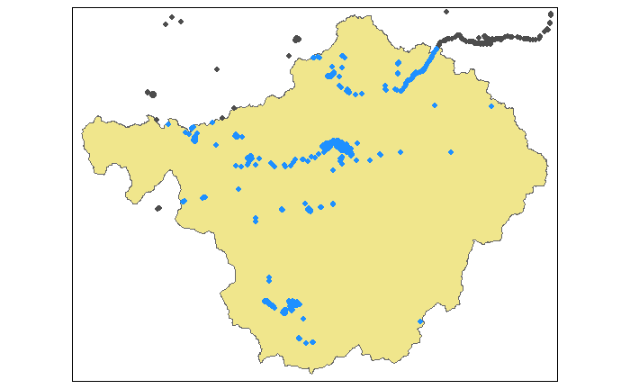

```r
## Plot
tm_shape(merced_hu_utm) +
  tm_polygons(col = "khaki") +
tm_shape(yose_poi_utm) +
  tm_dots(size = 0.2, col = "gray30") +
tm_shape(merced_poi_utm) +
  tm_dots(size = 0.2, col = "dodgerblue")
```

## End

Congratulations, you’ve completed another Notebook!

To view your Notebook at HTML, save it (again), then click the ‘Preview’ button in the RStudio toolbar.